# My title

Author

Affiliation

My name

Simon Fraser University

## Heading

### Subheading

Some text.

## Formatting

Note that each header automatically creates an anchor, making it easy to link to specific sections of your documents.

Text can be rendered *in italic* or **in bold** as well as underlined.

You can use superscripts<sup>2</sup>, subscripts<sub>test</sub>, strikethrough, and `inline code`.

> This is a quote.

## Columns

You can create columns.

And you can set their respective width.

## Lists

- Item 1
- Item 2
- Item 3

## Ordered lists

1. Item 1
2. Item 2
3. Item 3

## Images

[figure not shown]

Example image

## Tables

| Col 1 | Col 2 | Col 3 |
| --- | --- | --- |
| a | 1 | red |
| b | 2 | orange |
| c | 3 | yellow |

**Note**

Tables can be fully customized (or you could use raw html).

## Equations

$$\frac{\partial \mathrm C}{ \partial \mathrm t } + \frac{1}{2}\sigma^{2} \mathrm S^{2}
\frac{\partial^{2} \mathrm C}{\partial \mathrm C^2}
+ \mathrm r \mathrm S \frac{\partial \mathrm C}{\partial \mathrm S}\ =
\mathrm r \mathrm C$$

## Cross-references

See Section 2.

*Note that you can add bibliographies, flow charts, the equivalent of HTML “div”, and just so much more. Remember that this is a tiny overview.*

## Let’s try some code blocks now

```r
# This is a block that runs
2 + 3
```

```
[1] 5
```

Did you notice that the content of your code blocks can be copied with a click? Of course, this is customizable.

```r
# This is a block that doesn't run
2 + 3
```

[output not shown]

## Plots

```r
plot(cars)
```

[output not shown]

You can play with options to add a title:

```r
plot(cars)
```

[output not shown]

You can have more complex multi-plot layouts:

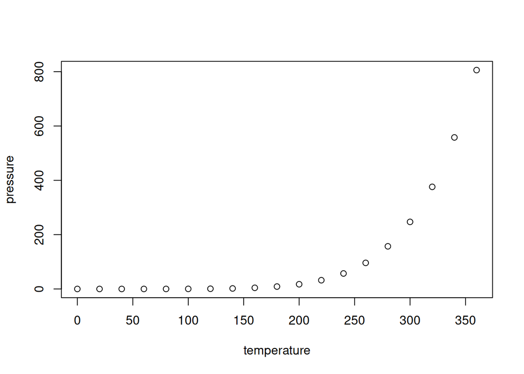

Vapor pressure of mercury as a function of temperature

```r
plot(cars)
plot(pressure)
```

[output not shown]

For those who have `ggplot2`[^1], you can try that too:

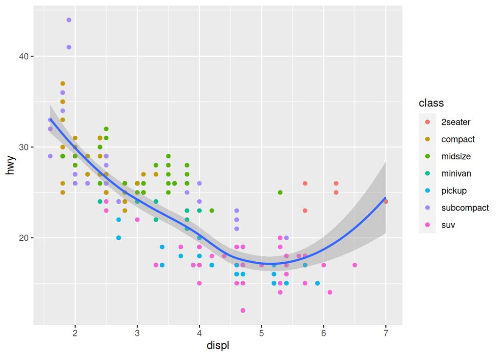

```r
library(ggplot2)

ggplot(data = mpg, mapping = aes(x = displ, y = hwy)) +
  geom_point(mapping = aes(color = class)) +
  geom_smooth()
```

## Footnotes

[^1]: You can install it with:

    ```r
    install.packages("ggplot2")
    ```